# Efficient Synchronization of Linux Memory Regions over a Network

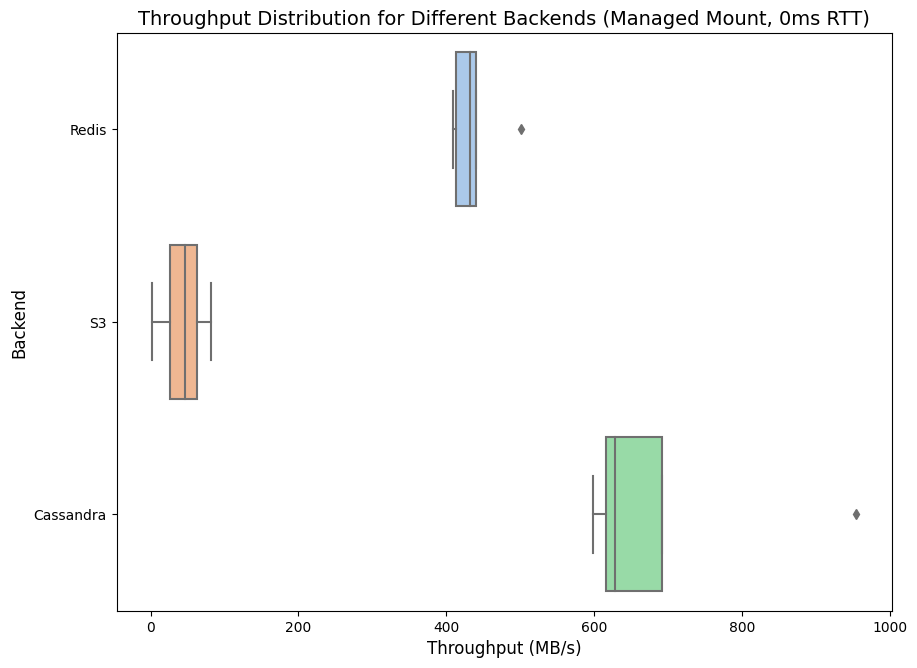

Box plot for the throughput distribution for Redis, S3 and ScylllaDB for managed mounts (0ms RTT)

As for the distribution, ScylllaDB has a high spread but also the highest throughput, while Redis has the lowest spread. S3 is also noticeably here with a consistently lower throughput compared to both alternatives, with an average spread.

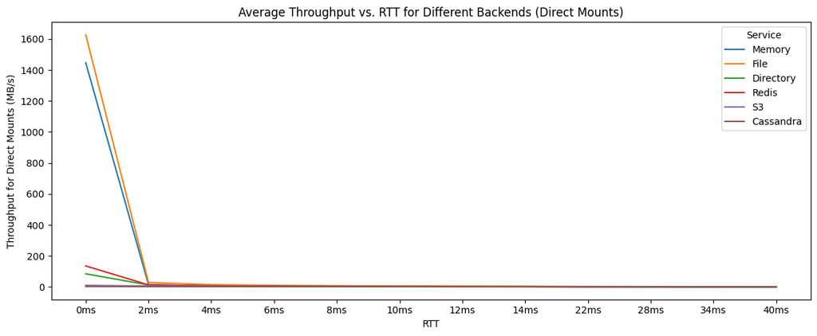

Average throughput for memory, file, directory, Redis, S3 and ScylllaDB backends for direct mounts by RTT

When looking at average throughput for direct mounts, all backends drop in throughput as RTT increases. Memory and file are very fast at above 1.4 GB/s at 0 ms RTT, while Redis achieves 140 MB/s as the closest network-capable alternative. The directory backend noticeably has a lower throughput than Redis, despite not being network-capable. All other backends are at below 15 MB/s for direct mounts, even at 0 ms RTT, and all backends trend towards below 3 MB/s at an RTT of 40 ms for direct mounts.

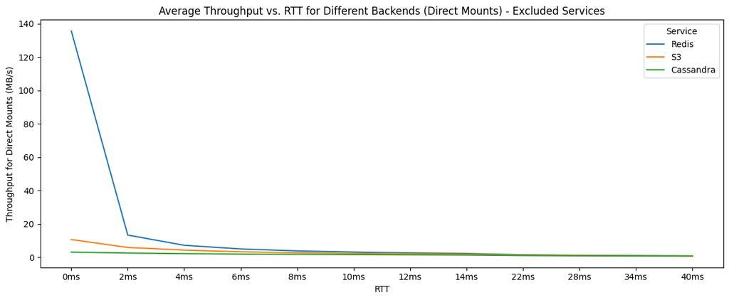

Average throughput for Redis, S3 and ScylllaDB backends for direct mounts by RTT

The network-capable backends in isolation again show the striking difference between Redis and the other backends’ direct mount performance, but all generally trend towards low throughput performance as RTT increases.

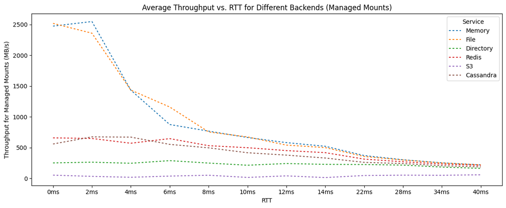

Average throughput for memory, file, directory, Redis, S3 and ScylllaDB backends for managed mounts by RTT

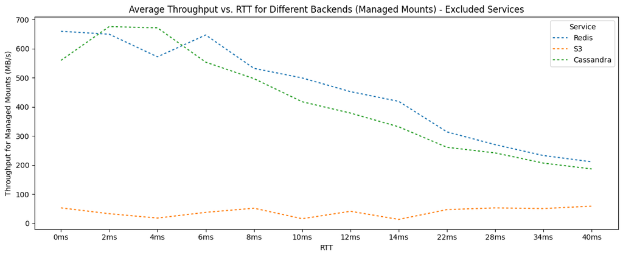

Average throughput for Redis, S3 and ScylllaDB backends for managed mounts by RTT

# 7 Discussion

## 7.1 Userfaults

`userfaultfd` is a simple way to map almost any object into memory. It is a comparatively simple approach, but also has significant architecture-related problems that limit its use. One problem is that it is only able to catch page faults, which means that it can only handle a data request the first time a chunk of memory gets accessed, since all future requests to a memory region handled by `userfaultfd` will simply return directly from RAM. This prevents the usage of this approach for accessing remote resources that update over time, and also makes it hard to use it for applications with concurrent writers or shared resources, since there would be no way of updating a section with a conflict.

Due to these limitations, `userfaultfd` is essentially limited to read-only mounts of remote resources, not synchronization. While it could be a viable solution for post-copy migration, it also prevents pulling chunks from being pulled before they have been accessed without adding a layer of indirection. The `userfaultfd` API socket is also synchronous, meaning that each page fault for each chunk needs to be handled one after the other, making it very vulnerable to high RTT scenarios. This also results in the initial read latency always being at least the RTT to the backend.

While it has a lower first chunk latency compared to direct mounts and managed mounts at 0 ms RTT (see figure ), the latency grows linearly as the RTT increases (see figure ) due to the aforementioned synchronous API socket and no way of pulling data in the background. While it has more predictable throughput and latency than the NBD-based solutions, for high RTT deployments, it becomes essentially unusable due to the low throughput. In summary, while this approach is interesting and idiomatic to Go and Linux, for most data, esp. larger datasets and high-RTT networks like a WAN, one of the alternative solutions is a better choice.

## 7.2 File-Based Synchronization

Similarly to `userfaultfd`, the approach based on `mmap`ing a memory region to a file and then synchronizing this file also has limitations. While `userfaultfd` is only able to catch the first reads to a file, this system is only able to catch wries, making it unsuitable for post-copy migration scenarios. It makes this system write-only, and very inefficient when it comes to adding hosts to the network at a later point, since all data needs to be continuously synchronized to all other hosts that state could potentially be migrated too.

To work around this issue, a central forwarding hub can be used, which reduces the amount of data streams required from the host currently hosting the data, but also adds other drawbacks such as operational complexity and additional latency. Still, thanks to this support for the central forwarding hub, file-based synchronization might be a good choice for highly throughput-constrained networks, but the inability to do post-copy migration due to it being write-only makes it a suboptimal choice for migration scenarios.

## 7.3 FUSE

File systems in user space provide a solution that allows for both pre- and post-copy migration, but doesn’t come without downsides. As it operates in user space, it depends on context switching, which does add additional overhead compared to a file system implementation in kernel space. While some advanced file system features like `inotify` and others aren’t available for a FUSE, the biggest problem is the development overhead of implementing a FUSE, which requires the implementation of a completely custom file system. The optimal solution for memory synchronization is not to provide an entire file system to track reads and writes on, but instead to track a single file; for this use case, NBD serves as an existing API providing this simpler approach, making FUSE not the optimal technology to implement memory synchronization with.

## 7.4 Direct Mounts

Direct mounts have a high spread when it comes to first chunk latency at 0 ms RTT(see figure ), but are more predictable when it comes to their throughput (see figure ). Similarly to the drawbacks of `userfaultfd`, it’s first chunk latency grows linearly as the RTT increases (see figure ), due to the lack of preemptive pulls. Despite this, it has the highest throughput at 0 ms RTT, even higher than managed mounts (see figure ) due to it having less expensive internal I/O operations as a result of the lack of this pull system. While compared to `userfaultfd`, its read throughput doesn’t drop as rapidly as RTT increases (see figure ), its write speed is heavily influenced by RTT (see figure ) since writes need to be written to the remote as they happen, as there is no background push system either. These characteristics make direct mounts a good access method to choose if the internal overhead of using managed mounts is higher than the overhead caused for direct mounts by the RTT, which can be the case in LAN or other very low-latency environments.

## 7.5 Managed Mounts

Managed mounts have an internal overhead to due to the duplicate I/O operations required for background pull and push, resulting in a worse throughput for low RTT scenarios compared to direct mounts (esp. for 0 ms RTT; see figure ), as well as higher first chunk latencies (see figure ). As soon as the RTT reaches levels more typical for a WAN environment however, this overhead becomes negligible compared to the benefits gained over the other access methods thanks to the background push and pull systems (see figure and ).

Adjusting the background workers to the specific environment can substantially increase a managed mounts’ performance (see figure and ), since data can be fetched in parallel. The pull priority function can allow for even more optimized pulls, and preemptive pulls can significantly reduce initial chunk latency since data can be pulled asynchronously before the device is even available. Higher worker counts to increase the amount of data that is being pulled preemptively (see figure ), as well as preferring polling over the `udev`-based method for detecting device readiness (see figure ) can reduce the overall device `Open()` time and thus reduce the initial overhead of using this access method for a remote resource. Write throughput for managed mounts is also significantly higher than for direct mounts (see figure ), which is the case due to the background push system; writes are first written to the faster local backend, and are then asynchronously written to the remote, resulting in much faster write speeds. These characteristics make managed mounts the preferred access method for WAN environments, where the RTT is usually more than high enough to balance out the internal overhead caused by the background push and pull systems I/O operations.

## 7.6 Chunking

In general, server-side chunking should almost always be the preferred technology due to the much better throughput compared to client-side chunking (see figure ). For direct mounts, due to their linear/synchronous access pattern, the throughput is low for both server- and client-side chunking as RTT increases, but even with linear access server-side chunking still outperforms the alternative (see figure ). For managed mounts, client-side chunking can still halve the throughput of a mount compared to server-side chunking (see figure ). If the data chunks are smaller than the NBD block size, it reduces the number of chunks that can be fetched if the number of workers remains the same. This isn’t the case with server-side chunking because it doesn’t need an extra worker on the client side for each additional chunk that needs to be fetched. This allows the background pull system to fetch more, thus increasing throughput.

## 7.7 RPC Frameworks

Out of the frameworks tested, Dudirekta consistently has lower throughput than the alternatives (see figure ). It performs better for managed mounts than direct mounts thanks to its support for concurrent RPCs and is less sensitive to RTT compared to gRPC and fRPC for managed mounts, but even for the latter, its throughput is much lower compared to both alternatives (see figure ) due to its lack of connecting pooling. Despite these drawbacks however, Dudirekta remains an interesting option for prototyping due to the decreased friction in developer overhead, bidirectional RPC support and transport layer independence.

gRPC offers considerably faster throughput compared to Dudirekta for both managed and direct mounts (see figure ). It has support for connection pooling, giving it a significant performance benefit over Dudirekta for managed mounts (see figure ), do to it being able to more efficiently pull chunks in the background concurrently. It also has good throughput for 0 ms RTT scenarios, and is essentially an industry standard, resulting in good tooling as well as known scalability characteristics.

While gRPC offers a throughput improvement compared to Dudirekta, fRPC is able to improve on gRPC even further due to its internal optimizations. It is also faster than Dudirekta in both direct and managed mounts (see figure ) due to its support for connection pooling, and compared to gRPC, is a more lean stack than gRPC and Protocol Buffers, making it more simple and maintainable. As a less commonly used solution however it also has less enterprise testing and tooling available, which means that is a more performant, but also less proven option.

## 7.8 Backends

Redis is the network-capable backend with the lowest amount of initial chunk latency at a 0 ms RTT (see figure ). When used for direct mounts, it has a lower throughput compared to managed mounts (see figure ), showing good support for concurrent chunk access; it also has the highest throughput for direct mounts by a significant margin (see figure ) due to its optimized wire protocol and fast key lookups. It also has good throughput in managed mounts due to these optimizations (see figure ), making it a good choice for ephemeral data like caches, where quick access times are necessary, or the direct mount API provides benefits, i.e. in LAN deployments.

ScylllaDB has the highest throughput for 0 ms RTT deployments for managed mounts, showing a very good concurrent access performance (see figure ). It does however fall short when it comes to usage in direct mounts, where the performance is worse than any other backend (see figure ), showing the databases high read latency overhead for looking up individual chunks, which is also backed up by looking at its initial chunk latency distribution (see figure ). For managed mounts however, as the RTT increases, it shows only slightly lower performance compared to Redis (see figure ); as a result, it is a good choice of backend if most data will be accessed concurrently by the managed mounts background pull system, but a bad choice if chunks will be accessed outside this due to the low direct mount throughput. Another use case where ScylllaDB can potentially be beneficial due to its configurable consistency is storing persistent data in a way that is more dependable than Redis or S3.

S3 has the lowest throughput of all network-capable backends that were implemented for managed mounts (see figure ). Its performance is consistently low even as RTT increases (see figure ), presumably due to the high overhead of having to make multiple HTTP requests to retrieve individual chunks, despite performing better than ScylllaDB for a direct mount scenario (see figure ). S3 remains a good choice of backends if its use is required due to architectural constraints, or if the chance of persistently stored chunks being read outside the managed mounts background pull system is high, where Casssandra has considerably worse throughput.

## 7.9 Limitations

While the mount APIs are functional for most use cases, there are performance and usability issues due it being implemented in Go. Go is a garbage collected language, and if the garbage collector is active, it has to stop certain Goroutines. If the `mmap` API is used to access a managed mount or a direct mount, it is possible that the garbage collector tries to manage an object with a reference to the exposed slice, or tries to release memory as data is being copied from the NBD device. If the garbage collector then tries to access the slice, it can stop the Goroutine providing the slice in the form of the NBD server, causing the deadlock. One workaround for this is to lock the `mmap`ed region into memory, but this will also cause all chunks to be fetched from the remote into memory, which leads to a high `Open()` latency; as a result, the recommended workaround for this is to simply start the NBD server in a separate process, to prevent the garbage collector from stopping the NBD server and trying to access the slice at the same time. Another workaround for this issue could be to instead use a language without a garbage collector such as Rust, which doesn’t allow for the deadlock to occur in the first place.

NBD, the underlying technology and protocol for the mount API, has proven to be fairly performant, but it could still be improved upon to get closer to the performance of other access methods, like raw memory access. One such option is `ublk`[65], which has the potential to significantly improve concurrent access speeds over the socket-based connection between the client and server that NBD uses. It is similar in architecture to NBD, where a user space server provides the block device backend, and a kernel `ublk` driver creates `/dev/ublkb*` block devices not unlike the `/dev/nbd*` devices created by NBD. At the point of this thesis being published however, documentation on this emerging kernel technology is still lacking, and NBD continues to be the standard way of creating block devices in user space.

## 7.10 Using Mounts for Remote Swap with `ram-dl`

`ram-dl`[66] is an experimental tech demo built to demonstrate how the mount API can be used. It uses the fRPC mount backend to expand local system memory, enabling a variety of use cases such as mounting a remote systems RAM locally or easily inspecting a remote systems’ memory contents.

It is based on the direct mount API and uses `mkswap`, `swapon` and `swapoff` to enable the Kernel to page out to the mount’s block device:

```go
// Create a swap partition on the block device
exec.Command("mkswap", devPath).CombinedOutput()

// Enable paging and swapping to the block device
exec.Command("swapon", devPath).CombinedOutput()

// When the mount is stopped, stop paging and swapping to the block device
defer exec.Command("swapoff", devPath).CombinedOutput()
```

`ram-dl` exposes two commands that achieve this. The first, `ram-ul` exposes RAM by exposing a memory, file or directory-based backend using a fRPC endpoint. `ram-dl` itself then connects to this endpoint, starts a direct mount and sets the block device up for swapping. While this system is intended mostly as a tech demo and, due to latency and throughput limitations, is not intended for critical deployments, it does show how simple using the r3map API can be, as the entire project consistent of under 300 source lines of code, most of which is argument handling and boilerplate around configuration.

## 7.11 Mapping Tape Into Memory With `tapisk`

### 7.11.1 Overview

`tapisk`[67] is a tool that exposes a tape drive as a block device. While seemingly unrelated to memory synchronization, it does serve as an interesting use case due to the similarities to STFS (mentioned earlier in the FUSE section), which exposed a tape drive as a file system, and serves as an interesting example for how even seemingly incompatible backends can be used to store and synchronize memory.

Using a tape drive as such a backend is challenging, since they are designed for linear access and don’t support random reads, while block devices need support for reading and writing to arbitrary locations. Tapes also have very high read/write latencies due to slow seek speeds, taking up to more than a minute to seek to a specific record depending on the offset of the tape that is being accessed. Due to the modularity of r3map’s managed mount API however, it is possible to work around these issues, and still make the tape appear as a random-access block device.

### 7.11.2 Implementation

To achieve this, the background writes and reads provided by the managed mount API can be used. Using these, a faster storage backend (i.e. the disk) can be used as a caching layer, although the concurrent push/pull system can’t be used due to tapes only supporting synchronous read/write operations. By using the managed mount, writes are de-duplicated and both read and write operations can become asynchronous, since both happen on the fast local backend first, and the background synchronization system them handles either periodic writebacks to the tape for write operations or reading a chunk from the tape if it is missing from the cache.

Since chunking works differently for tapes than for block devices, and tapes are append-only devices where overwriting a section prior to the end would result in all following data being overwritten, too, an index must be used to simulate the offsets of the block device locations to their physical location on the tape, which the `bbolt` database is used for. In order to make non-aligned reads and writes to the tape possible, the existing `ArbitraryReadWriter` system can be used. When a chunk is then requested to be read, `tapisk` looks up the physical tape record for the requested offset, and uses the accelerated `MTSEEK` ioctl to seek to the matching record on the tape, after which the chunk is read from the tape into memory:

```go
func (b *TapeBackend) ReadAt(p []byte, off int64) (n int, err error) {
    // Calculating the block for the offset
    block := uint64(off) / b.blocksize

    // Getting the physical record on the tape from the index
    location, err := b.index.GetLocation(block)
    // ...

    // Creating the seek operation
    mtop := &ioctl.Mtop{}
    mtop.SetOp(ioctl.MTSEEK)
    mtop.SetCount(location)

    // Seeking to the record
    syscall.Syscall(
        syscall.SYS_IOCTL,
        drive.Fd(),
        ioctl.MTIOCTOP,
        uintptr(unsafe.Pointer(mtop)),
    )
    // ...

    // Reading the chunk from the tape into memory
    return b.drive.Read(p)
}
```

Conversely, in order to write a chunk to the tape, `tapisk` seeks to the end of the tape (unless the last operation was a write already, in which case the tape must be at the end already). Once the seek has completed, the current physical record is requested from the tape drive, and stored as the record for the block that is to be written in the index, after which the chunk is written to the tape. This effectively makes it possible to overwrite existing chunks despite the tape being append-only, since subsequent writes to the same chunk result in the changes being written to the end of the file with the index referencing the new physical location, but does come at the cost of requiring defragmentation to clean up prior iterations of chunks.

### 7.11.3 Evaluation

`tapisk` is a unique application of r3map’s technology, and shows how flexible it is. By using this index, the effectively becomes tape a standard `ReadWriterAt` stage (and `go-nbd` backend) with support for aligned-reads in the same way as the file or directory backends, and thanks to r3map’s pipeline design, the regular chunking system could be reused, unlike in STFS where it had to be built from scratch. By re-using the universal RPC backend introduced earlier, which can give remote access to any `go-nbd` backend over an RPC library like Dudirekta, gRPC or fRPC, it is also possible to access a remote tape this way, i.e. to map a remote tape library robot’s drive to a system over the network.

Being able to map a tape into memory without having to read the entire contents first can have a variety of use cases. Tapes can store a large amount of data, in the case of LTO-9, up to 18 TB on a single tape[68]; being able to access such a large amount of data directly in memory, instead of having to work with tooling like `tar`, can significantly improve developer experience. In addition to making it much easier to access tape drives, `tapisk` can also serve as a replacement for Linear Tape File System (LTFS). LTFS is a another custom file system implemented as a kernel module, which also allows for mounting a tape. If a `tapisk`-provided block device is formatted with a file system such as EXT4 or Btrfs, it can also be mounted locally, allowing the tape to be mounted as a file system as well, with the added benefit of also being able to support any file system that supports block devices as their backend. Compared to the LTFS approach, which is implemented as a kernel module, this results in a much more maintainable project; while LTFS is tens of thousands of kernel-level source lines of code, `tapisk` achieves effectively the same use case with just under 350.

## 7.12 Improving Cloud Storage Clients

### 7.12.1 Existing Solutions

r3map can also be used to create mountable remote file systems with unique advantages over existing solutions. Currently, there are two main approaches to implementing cloud storage clients. Dropbox and Nextcloud are examples of systems that listen to file changes on a folder and synchronizes files as changes are detected, similarly to the file-based memory region synchronization approach discussed earlier. The big drawback of this approach is that everything that should be available needs to be stored locally; if a lot of data is stored in the cloud drive, it is common to only choose to synchronize a certain set of data to the local host, as there is no way to dynamically download files as they are being accessed. Read and write operations on such systems are however very efficient, since the system’s file system is used and any changes are written to/from this file system asynchronously by the synchronization client. This approach also makes offline availability easy, as files that have been synchronized to the local system stay available even if network connectivity has been lost.

The other currently used option is to use a FUSE, i.e. `s3fs`[29], which allows for files to be fetched on demand, but comes with a heavy performance penalty. This is the case because most implementations, if a write or read request is sent from the kernel to the FUSE, remote writes or reads happen directly over the network, which makes this approach very sensitive to networks with a high RTT. Offline usage is also usually not possible with a FUSE-based approach, and features such as `inotify`, symlinks etc. are hard to implement, leaving two imperfect solutions to implementing a cloud storage client.

### 7.12.2 Hybrid Approach

Using r3map makes it possible to get the benefits of both approaches by not having to download any files in advance and also being able to write back changes asynchronously, as well as being able to use almost any existing file system with its complete feature set. Files can also be downloaded preemptively to allow for offline access, just like with the approach that listens to file changes in a directory.

This is possible by once again using the managed mount API. The block device is formatted using a valid file system, i.e. EXT4, and then mounted on the host. By configuring the background pull systems workers and pull priority function, it is possible to also download files for offline access, and files have not yet been downloaded to the local system can be pulled from the remote backend as their chunks are being accessed. If a chunk is available locally, reads are also much faster than they would be with a FUSE implementation, and since writes are made to the local backend first, and then being synchronized back to the remote using the remote push system, the same applies to the writes too. Furthermore, by using the migration API, it is possible to migrate the file system between two hosts in a highly efficient way.

By combining the advantages of both approaches into a hybrid one, it is possible to bridge the gap between them, showing that memory synchronization technology like r3map can be used to not only synchronize memory regions, but other state too, including disks.

## 7.13 Universal Database, Media and Asset Streaming

### 7.13.1 Streaming Access to Remote Databases

Another use case that r3map can be used for is accessing a remote database locally. While using a database backend (such as the ScylllaDB backend introduced earlier) is one option of storing the chunk, this use case is particularly interesting for file-based databases like SQLite that don’t define a wire protocol. Using r3map, instead of having to download an entire SQLite database before being able to use it, it can instead be mounted with the mount API, which then fetches the necessary offsets from a remote backend storing the database as they are being accessed. For most queries, not all data in a database is required, especially if indexes are used; this makes it possible to potentially reduce the amount of transferred data by streaming in only what is required.

Since reads are cached using the local backend with the managed mount API, only the first read should potentially have a performance impact (if it has not been pulled first by the background pull system); similarly so, since writes are written to the local backend first, and then asynchronously written back, the same applies to them as well. Moreover, if the location of i.e. indexes within the SQLite database is known, a pull heuristic can be specified to fetch these first to speed up initial queries. Thanks to the managed mount API providing a standard block device, no changes to SQLite are required in order for it to support such streaming access; the SQLite file could simply be stored on a mounted file system provided by the mount’s block device.

### 7.13.2 Making Arbitrary File Formats Streamable

In addition to making databases streamable, r3map can also be used to access files in formats that usually don’t support being accessed before they are fully available locally. One such format is MP4; usually, if a user downloads a MP4 file, they can’t start playback before the file is available locally completely. This is because MP4 typically stores metadata at the end of the file.

The reason for this being stored at the end is usually that the parameters required for this metadata requires encoding the video first. This results in a scenario where, assuming that the file is downloaded from the first to the last offset, the client needs to wait for the file to be completely accessible locally before playing it. While MP4 and other formats supports ways to encode such metadata in the beginning or once every few chunks in order to make them streamable, this is not the case for many already existing files and comes with other tradeoffs[69].

By using r3map however, the pull heuristic function can be used to immediately pre-fetch the metadata, independently of where it is placed; the rest of the chunks can then be fetched either by using the background pull system and/or ad-hoc as they are being accessed. Similarly to the approach used to stream in remote databases, this does not require any changes to the media player being used, since the block device providing the resource can simply be mounted as a file system and thus be used transparently.

### 7.13.3 Streaming App and Game Assets

Another streaming use case relates to the in-place streaming of assets. Usually, a game needs to be fully downloaded before it is playable; for many modern high-budget titles, this can be hundreds of gigabytes of data, resulting in very long download times even on fast internet connections. Usually however, not all assets need to be downloaded before the game can be played; only some of them are, i.e. the launcher, UI libraries or the first level’s assets. While theoretically it would be possible to design a game engine in such a way that assets are only fetched from a remote as they are being required, this would require extensive changes to most engine’s architecture, and also be hard to port back to existing titles; furthermore, current transparent solutions that can fetch in assets (i.e. mounting a remote NBD drive or FUSE) are unlikely to be viable solutions considering their high sensitivity to network latency and the high network throughput required for streaming in these assets.

By using the managed mount API to stream in the assets instead, the overhead of such a solution can be reduced, without requiring changes to the game or its engine. By using the background pull system, reads from chunks that have already been pulled are almost as fast as native disk reads, and by analyzing the access pattern of an existing game, a pull heuristic function can be generated which preemptively pulls the game assets that are loaded first, keeping latency spikes as low as possible. Thanks to using the callbacks for monitoring the pull progress provided by the managed mounts, the game can also be paused until a certain local chunk availability is reached in order to prevent latency spikes from missing assets that would need to be fetched directly from the remote, while still allowing for faster startup times.

This concept is not limited to games however, and could also be applied to launching any application. For many systems, completely scanning a binary or script into memory isn’t required for it to start execution; similarly to the situation of game engines, adding streaming support would require changes to the interpreters or VMs, since they don’t provide a streaming API out of the box aside from being able to read files from the file system. With the managed mount API, this existing interface can be reused to add streaming support to these systems by simply pointing them to a file system provided by the mount’s block device, or, if the interpreter/VM supports it, `mmap`ing the block device directly and executing the resulting memory region.

## 7.14 Universal App State Mounts and Migrations

### 7.14.1 Modelling State

Synchronization of app state is a fairly complex problem, and even for simple scenarios, a custom protocol is typically built for apps. While it is possible to use real-time databases like Firebase to synchronize some application states, Firebase and similar solutions to it are usually limited in which data structures they can store and require specific APIs to synchronize them. Usually, even for a simple migration of state between two hosts, synchronization requires state to be manually marshalled, sent over a network, received on a destination host, and unmarshalled. This requires a complex synchronization protocol, and decisions such as when to synchronize state and when to start pulling from the remote need to be made manually, which often results in a database on a third host being used even for simple migrations from one host to another instead of implementing a peer-to-peer process. Almost all of these data structures can ultimately be represented by a byte array; by allocating them from a slice `mmap`ed by r3map, it is possible to use the managed mount, direct mount or migration APIs to implement a universal way of both synchronization and migration of application state, without having to implement a custom protocol.

### 7.14.2 Mounting State

By allocating all structures on r3map’s provided `mmap`ed byte slice, many interesting use cases become possible. For example, a TODO app could use it as its backend. Once loaded, the app mounts the TODO list as a byte slice from a remote server using the managed mount API; since authentication is pluggable and i.e. a database backend like ScylllaDB with a prefix for this user provides a way to do both authentication and authorization, such an approach can scale fairly well. Using the preemptive background pull system, when the user connects, they can not only start streaming in the byte slice from the remote server as the app is accessing it, but also pull the majority of the required data first by using the pull heuristic function. If the TODO list is modified by changing it in the `mmap`ed memory region, the changes are asynchronously written back to the underlying block device, and thus to the local backend, where the asynchronous writebacks can synchronize them back to the remote. If the local backend is persistent, i.e. file-based, such a system can even survive network outages.

### 7.14.3 Migrating State

In addition to using managed mounts to access remotely stored application state, migration of arbitrary app state also becomes a possibility. If a user has a TODO app running on a host like their smartphone, but wants to continue writing a task description on their desktop system, they can migrate the app’s state directly and without a third party/remote database by using r3map. For this use case, the migration API can be used. In order to optimize the migration, the pre-copy phase can be started automatically, i.e. if the phone and desktop are physically close to each other or in the same network; in such a LAN migration case, the process is able to benefit from low latencies and high throughput. It is also possible to integrate the migration API deeply with system events, i.e. by registering a service that migrates applications off a system before a shutdown procedure completes.

### 7.14.4 Migrating Virtual Machines

It is important to note that there are a few limitations with synchronizing and migrating an application’s internal stateful data structures this way; locking is not handled by r3map and would need to be done using a higher-level protocol; moreover, this assumes that the in-memory representation of the data structure is consistent across all hosts, something which is not necessarily the case with programming languages such as Go with multiple processor architectures being involved. While projects such as Apache Arrow[70] allow for application state to represented in a language and CPU architecture independent way, this comes with some of the same restrictions on which state can be synchronized as with other solutions such as Firebase.

In order to keep the possibility of migrating arbitrary state, but also allow for cross-architecture compatibility, VMs can be used. Keeping with the TODO app example, if the resulting app is compiled to Wasm, instead of having to allocate all memory that is to be synchronized from the r3map-provided `mmap`ed byte slice, it is possible to instead simply synchronize the Wasm VM’s linear memory as a whole, which also allows storing the entire app’s state on a remote as well as migrating an entire app. Similarly so, the app’s binary, mounted WASI file systems etc. could all be synchronized this way, too. Thanks to the preemptive pull implementation outlined earlier, the VM startup and device initialization can also be made concurrent to allow for shorter latencies while resuming the VM.

This capability is not limited to Wasm VMs however; rather, it is possible to add these features to almost any hypervisor or virtual machine that supports mapping an application’s/virtual machine’s state to a block device or memory region, essentially adding the capability to suspend/resume and migrate any application in the same way that is possible today over WAN, without requiring any or only minimal changes to the applications themselves.

# 8 Summary

As is evident from the discussion, there are multiple ways and configurations for implementing a solution for universally accessing, synchronizing and migrating memory regions, with the individual configurations having different strengths and weaknesses as shown by the benchmarks, making them each suitable for different use cases.

When it comes to access methods, `userfaultfd` is an interesting API that is idiomatic to both Linux in as a first-party solution and Go due to its fairly low implementation overhead. This approach however falls short when it comes to throughput, especially when used in WAN, where other options can provide better performance. The delta synchronization method for `mmap`ed files provides a simple way of memory synchronization for specific scenarios, but does have a very significant I/O and compute overhead due to its polling and hashing requirements that make it unsuitable for most applications; similarly so, FUSE provides an extensive API for implementing a complete file system in user space, but has significant implementation overhead making it a suboptimal choice for memory synchronization. Block device-based direct mounts provide an access method for LAN deployment scenarios, where networks typically have low latency and the lack of I/O overhead compared to other methods makes it a compelling choice, while managed mounts are the preferred access method for WAN environments. This is due to their efficient use of background push and pull, making it possible for them to adapt to the high latencies typical for such deployments, despite having slightly higher internal I/O overhead compared to direct mounts. For most real-world applications, the mount and migration APIs provide a fast and reliable way of achieving a truly universal method of working with remote memory and resources.

As for RPC framework and transport choice, most production environments are well-suited for both fRPC and gRPC as high-performance options, where fRPC can offer slightly better average throughput, compared to gRPC’s better developer tooling as a result of its longstanding legacy. For backend choice, the file backend provides a good option for memory migration and synchronizations, as it can provide a performant, reliable and persistent way of storing a memory region without using up too much host memory. For memory access use cases, Redis shows consistently strong throughput in both managed and direct mount scenarios due to its concurrency optimizations, especially if ephemeral data is accessed in LAN environments, while Cassandra (and ScyllaDB) provide a good option for applications using managed mounts that need strong concurrency guarantees. These different approaches show that is possible to adapt the semantics for accessing, synchronizing and migrating resources backed by memory regions to a wide variety of backends, wire protocols and APIs.

# 9 Conclusion

The proposed solution consisting of the direct mount, managed mount and migration APIs as implemented in the form of the r3map library present an efficient method of accessing, synchronizing and migrating remote memory regions over a network, with example use cases and benchmarks showing that r3map is able to provide both throughput and latency characteristics that make it possible to use as part of applications today.

While there are limitations with the proposed solution’s underlying technologies, these do provide future research opportunities. For example, the use of Rust as a language that is garbage collection-free could be studied as an option to further increase throughput, fix encountered deadlock issues and reduce overall resource usage, and exploring emerging alternatives to NBD for creating block devices in user space such as `ublk` could help further improve the implementation presented.

Despite these limitations, the promise of providing a truly universal way of working with remote memory, without having to significantly change existing applications or hypervisors, is provided in the form of the reference implementation. It is also able to use specialized configurations for LAN and WAN, making it possible to apply remote memory technology in completely different and much more dynamic environments than before. As a result, entirely new ways of thinking about application architecture and lifecycles become possible, which can help enable the applications of tomorrow to become both simpler to maintain and more scalable than those built today.

# Bibliography

[1]

W. Mauerer, *Professional linux kernel architecture*. Indianapolis, IN: Wiley Publishing, Inc., 2008, pp. 2–4, 7–8, 474–487, 1026–1027.

[2]

A. S. Tanenbaum and A. S. Woodhull, “Operating systems: Design and implementation,” 3rd ed., Upper Saddle River, NJ 07458: Pearson Education, Inc. Pearson Prentice Hall, 2006, pp. 27–29.

[3]

D. DeVault, “A hare code generator for finding ioctl numbers.” 2022. Accessed: Jul. 28, 2023. [Online]. Available: https://drewdevault.com/2022/05/14/generating-ioctls.html

[4]

Kernel Development Community, “Quick start.” 2023. Accessed: Jul. 19, 2023. [Online]. Available: https://www.kernel.org/doc/html/next/rust/quick-start.html

[5]

R. Love, *Linux kernel development*, 3rd ed. Pearson Education, Inc., 2010, pp. 8, 343–344.

[6]

W. R. Stevens, *Advanced programming in the UNIX environment*. Delhi: Addison Wesley Logman (Singapore) Pte Ltd., Indian Branch, 2000, pp. 19, 407–411.

[7]

K. A. Robbins and S. Robbins, *Unix™ systems programming: Communication, concurrency, and threads*. Prentice Hall PTR, 2003, p. 313.

[8]

W. R. Stevens, B. Fenner, and A. M. Rudoff, *UNIX® network programming volume 1, third edition: The sockets networking API*. Addison Wesley, 2003, pp. 507–531.

[9]

W. Stallings, *Computer organization and architecture: Designing for performance*. Upper Saddle River, New Jersey, 07458: Pearson Education, Inc., 2010, pp. 153, 114–116.

[10]

A. J. Smith, “Cache memories,” *ACM Comput. Surv.*, vol. 14, no. 3, p. 474, Sep. 1982, doi: 10.1145/356887.356892.

[11]

J. Barr, “New - offline tape migration using AWS snowball edge.” 2021. Accessed: Jul. 19, 2023. [Online]. Available: https://aws.amazon.com/blogs/aws/new-offline-tape-migration-using-aws-snowball-edge/

[12]

H. A. Maruf and M. Chowdhury, “Memory disaggregation: Advances and open challenges.” 2023.Available: https://arxiv.org/abs/2305.03943

[13]

J. Bonwick, “The slab allocator: An Object-Caching kernel,” Jun. 1994.Available: https://www.usenix.org/conference/usenix-summer-1994-technical-conference/slab-allocator-object-caching-kernel

[14]

M. Gorman, *Understanding the linux virtual memory manager*. Upper Saddle River, New Jersey 07458: Pearson Education, Inc. Publishing as Prentice Hall Professional Technical Reference, 2004, pp. 53–57, 179.

[15]

Kernel Development Community, “Swap suspend,” 2023. https://www.kernel.org/doc/html/latest/power/swsusp.html (accessed Jul. 19, 2023).

[16]

A. Silberschatz, P. B. Galvin, and G. Gagne, *Operating system concepts*, 10th ed. Hoboken, NJ: Wiley, 2018, pp. 425–426.Available: https://lccn.loc.gov/2017043464

[17]

J. Choi, J. Kim, and H. Han, “Efficient memory mapped file I/O for In-Memory file systems,” Jul. 2017.Available: https://www.usenix.org/conference/hotstorage17/program/presentation/choi

[18]

M. Prokop, “Inotify: Efficient, real-time linux file system event monitoring,” Apr. 2010. https://www.infoq.com/articles/inotify-linux-file-system-event-monitoring/ (accessed Jul. 19, 2023).

[19]

A. S. Tanenbaum, *Computer networks*. Pearson Education, Inc. Publishing as Prentice Hall PTR, 2003, pp. 21, 23.

[20]

“Transmission Control Protocol.” RFC 793; J. Postel, Sep. 1981. doi: 10.17487/RFC0793.

[21]

“User Datagram Protocol.” RFC 768; J. Postel, Aug. 1980. doi: 10.17487/RFC0768.

[22]

E. Rescorla, “The Transport Layer Security (TLS) Protocol Version 1.3.” RFC 8446, Aug. 2018. doi: 10.17487/RFC8446.

[23]

J. Iyengar and M. Thomson, “QUIC: A UDP-Based Multiplexed and Secure Transport.” RFC 9000; RFC Editor, May 2021. doi: 10.17487/RFC9000.

[24]

A. Langley *et al.*, “The QUIC transport protocol: Design and internet-scale deployment,” in *Proceedings of the conference of the ACM special interest group on data communication*, 2017, pp. 183–196. doi: 10.1145/3098822.3098842.

[25]

H. Xiao *et al.*, “Towards web-based delta synchronization for cloud storage services,” in *16th USENIX conference on file and storage technologies (FAST 18)*, Feb. 2018, pp. 155–168.Available: https://www.usenix.org/conference/fast18/presentation/xiao

[26]

libfuse Contributors, “FUSE minimal example filesystem using high-level API.” 2020. Accessed: Jul. 19, 2023. [Online]. Available: https://github.com/libfuse/libfuse/blob/master/example/hello.c

[27]

W. Commons, “File:FUSE structure.svg - wikimedia commons, the free media repository.” 2023. Accessed: Jul. 30, 2023. [Online]. Available: https://commons.wikimedia.org/w/index.php?title=File:FUSE_structure.svg&oldid=762474154

[28]

B. K. R. Vangoor, V. Tarasov, and E. Zadok, “To FUSE or not to FUSE: Performance of User-Space file systems,” in *15th USENIX conference on file and storage technologies (FAST 17)*, Feb. 2017, pp. 59–72.Available: https://www.usenix.org/conference/fast17/technical-sessions/presentation/vangoor

[29]

A. Gaul and T. Nakatani, “s3fs: FUSE-based file system backed by amazon S3.” 2023. Accessed: Jul. 19, 2023. [Online]. Available: https://github.com/s3fs-fuse/s3fs-fuse

[30]

libfuse Contributors, “SSHFS: A network filesystem client to connect to SSH servers.” 2022. Accessed: Jul. 19, 2023. [Online]. Available: https://github.com/libfuse/sshfs

[31]

E. Blake, W. Verhelst, and other NBD maintainers, “The NBD protocol.” Apr. 2023. Accessed: Jul. 18, 2023. [Online]. Available: https://github.com/NetworkBlockDevice/nbd/blob/master/doc/proto.md

[32]

P. Clements, “[PATCH] nbd: Increase default and max request sizes.” Apr. 02, 2013. Accessed: Jul. 19, 2023. [Online]. Available: https://lore.kernel.org/lkml/20130402194120.54043222C0@clements/

[33]

W. Verhelst, *Nbd-client man page*. 2023. Accessed: Jul. 19, 2023. [Online]. Available: https://manpages.ubuntu.com/manpages/lunar/en/man8/nbd-client.8.html

[34]

S. He, C. Hu, B. Shi, T. Wo, and B. Li, “Optimizing virtual machine live migration without shared storage in hybrid clouds,” in *2016 IEEE 18th international conference on high performance computing and communications; IEEE 14th international conference on smart city; IEEE 2nd international conference on data science and systems (HPCC/SmartCity/DSS)*, 2016, pp. 921–928. doi: 10.1109/HPCC-SmartCity-DSS.2016.0132.

[35]

A. Baruchi, E. Toshimi Midorikawa, and L. Matsumoto Sato, “Reducing virtual machine live migration overhead via workload analysis,” *IEEE Latin America Transactions*, vol. 13, no. 4, pp. 1178–1186, 2015, doi: 10.1109/TLA.2015.7106373.

[36]

T. Akidau, S. Chernyak, and R. Lax, *Streaming systems*. Sebastopol, CA: O’Reilly Media, Inc., 2018, pp. 23–25.

[37]

J. D. Peek, *UNIX power tools*. Sebastopol, CA; New York: O’Reilly Associates; Bantam Books, 1994, pp. 4–5.

[38]

A. A. A. Donovan and B. W. Kernighan, *The go programming language*. Addison-Wesley Professional, 2015, pp. 217–221, 255–227.

[39]

gRPC Contributors, “Introduction to gRPC.” 2023. Accessed: Jul. 18, 2023. [Online]. Available: https://grpc.io/docs/what-is-grpc/introduction/

[40]

Loophole Labs, Inc, “fRPC: A modern RPC framework designed for high performance and stability.” 2022. Accessed: Jul. 23, 2023. [Online]. Available: https://frpc.io/getting-started/overview

[41]

S. Vij, A. Sørlie, F. Pojtinger, and J. Sun, “Frisbee-go: Bring-your-own protocol messaging framework designed for performance and stability.” 2022. Accessed: Jul. 28, 2023. [Online]. Available: https://github.com/loopholelabs/frisbee-go

[42]

S. Vij, A. Sørlie, and F. Pojtinger, “Polyglot: A high-performance serialization framework used for encoding and decoding arbitrary data structures across languages.” 2022. Accessed: Jul. 23, 2023. [Online]. Available: https://github.com/loopholelabs/polyglot

[43]

Redis Ltd, “Introduction to redis.” 2023. Accessed: Jul. 18, 2023. [Online]. Available: https://redis.io/docs/about/

[44]

Redis Ltd, “Redis pub/sub.” 2023. Accessed: Jul. 18, 2023. [Online]. Available: https://redis.io/docs/interact/pubsub/

[45]

Amazon Web Services, Inc, “What is amazon S3?” 2023. Accessed: Jul. 18, 2023. [Online]. Available: https://docs.aws.amazon.com/AmazonS3/latest/userguide/Welcome.html

[46]

MinIO, Inc, “Core administration concepts.” 2023. Accessed: Jul. 18, 2023. [Online]. Available: https://min.io/docs/minio/kubernetes/upstream/administration/concepts.html

[47]

A. Lakshman and P. Malik, “Cassandra: A decentralized structured storage system,” *SIGOPS Oper. Syst. Rev.*, vol. 44, no. 2, pp. 35–40, Apr. 2010, doi: 10.1145/1773912.1773922.

[48]

P. Grabowski, J. Stasiewicz, and K. Baryla, “Apache cassandra 4.0 performance benchmark: Comparing cassandra 4.0, cassandra 3.11 and scylla open source 4.4,” ScyllaDB Inc, 2021.Available: https://www.scylladb.com/wp-content/uploads/wp-apache-cassandra-4-performance-benchmark-3.pdf

[49]

F. Pojtinger, “r3map: Efficient remote memory region mounting and migration.” 2023. Accessed: Jul. 31, 2023. [Online]. Available: https://github.com/pojntfx/r3map

[50]

J. Corbet, “4.3 merge window, part 2.” 2015. Accessed: Jul. 20, 2023. [Online]. Available: https://lwn.net/Articles/656731/

[51]

F. Pojtinger, “Userfaultfd-go: Go bindings to userfaultfd.” 2022. Accessed: Jul. 31, 2023. [Online]. Available: https://github.com/loopholelabs/userfaultfd-go

[52]

F. Pojtinger, “STFS file system unit tests.” 2022. Accessed: Jul. 20, 2023. [Online]. Available: https://github.com/pojntfx/stfs/blob/main/pkg/fs/filesystem_test.go

[53]

S. Francia, “Fs interface - afero: A FileSystem abstraction system for go.” 2023. Accessed: Jul. 20, 2023. [Online]. Available: https://pkg.go.dev/github.com/spf13/afero#Fs

[54]

F. Pojtinger, “STFS: Simple Tape File System, a file system for tapes and tar files.” 2022. Accessed: Jul. 20, 2023. [Online]. Available: https://github.com/pojntfx/stfs

[55]

J. Waibel and F. Pojtinger, “sile-fystem: A generic FUSE implementation.” 2022. Accessed: Jul. 20, 2023. [Online]. Available: https://github.com/jakWai01/sile-fystem

[56]

F. Pojtinger, “go-nbd: Pure Go NBD server and client library.” 2023. Accessed: Jul. 31, 2023. [Online]. Available: https://github.com/pojntfx/go-nbd

[57]

T. Grieger, “The cost and complexity of cgo.” Dec. 2015. Accessed: Jul. 21, 2023. [Online]. Available: https://www.cockroachlabs.com/blog/the-cost-and-complexity-of-cgo/

[58]

F. Pojtinger, “Weron: Overlay networks based on WebRTC.” 2023. Accessed: Jul. 21, 2023. [Online]. Available: https://github.com/pojntfx/weron

[59]

Linux Kernel Contributors, “NBD kernel module in the linux kernel source tree.” 2023. Accessed: Jul. 21, 2023. [Online]. Available: https://git.kernel.org/pub/scm/linux/kernel/git/torvalds/linux.git/tree/drivers/block/nbd.c#n2592

[60]

F. Pojtinger, “Dudirekta: Transport-agnostic framework that allows exposing and calling functions on both clients and servers.” 2023. Accessed: Jul. 22, 2023. [Online]. Available: https://github.com/pojntfx/dudirekta

[61]

F. Pojtinger, “Dudirekta: WebRTC transport layer example.” 2023. Accessed: Jul. 22, 2023. [Online]. Available: https://github.com/pojntfx/dudirekta/blob/main/cmd/dudirekta-example-webrtc-peer/main.go

[62]

I. Ward, “Documentation for the JSON lines text file format.” 2013. Accessed: Jul. 28, 2023. [Online]. Available: https://jsonlines.org/

[63]

Loophole Labs, Inc, “fRPC: gRPC benchmarks.” 2022. Accessed: Jul. 30, 2023. [Online]. Available: https://frpc.io/performance/grpc-benchmarks

[64]

F. Pojtinger, “GitHub Repository for Efficient Synchronization of Linux Memory Regions over a Network: A Comparative Study and Implementation.” Aug. 2023.Available: https://github.com/pojntfx/networked-linux-memsync

[65]

Kernel Development Community, “Userspace block device driver (ublk driver),” 2023. https://docs.kernel.org/block/ublk.html (accessed Jul. 28, 2023).

[66]

F. Pojtinger, “Ram-dl: A tool to download more RAM (yes, seriously!).” 2023. Accessed: Jul. 23, 2023. [Online]. Available: https://github.com/pojntfx/ram-dl

[67]

F. Pojtinger, “Tapisk: Expose a tape drive as a block device.” 2023. Accessed: Jul. 23, 2023. [Online]. Available: https://github.com/pojntfx/tapisk

[68]

LTO Program, “The LTO program releases specifications for upcoming generation 9.” 2020. Accessed: Jul. 23, 2023. [Online]. Available: https://www.lto.org/2020/09/the-lto-program-releases-specifications-for-upcoming-generation-9/

[69]

M. Levkov, “Understanding the MPEG-4 movie atom.” Adobe Developer Network, 2020. Accessed: Jul. 30, 2023. [Online]. Available: https://web.archive.org/web/20210130152901/https://www.adobe.com/devnet/video/articles/mp4_movie_atom.html

[70]

Apache Software Foundation, “Apache arrow website.” 2023. Accessed: Jul. 23, 2023. [Online]. Available: https://arrow.apache.org/